# Analysis of Used and New Sports Cars from sportovnivozy.cz

Denis Vejrážka

2025-02-13

### Introduction

We will analyze cars whose data was collected from the website sportovnivozy.cz using the webscraping method the car prices range from 50,000 CZK to 29,900,000 CZK. There are 1,241 vehicles in total, of which 39 are new.

### Year of Manufacture

The year of manufacture of the vehicles spans a very wide range, including both vintage cars and new models. The histogram shows a leftward skew.

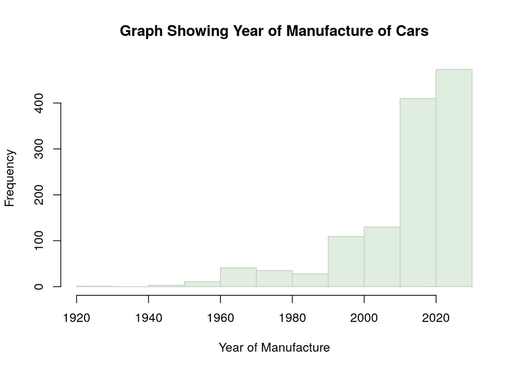

### Price Analysis of Sports Cars

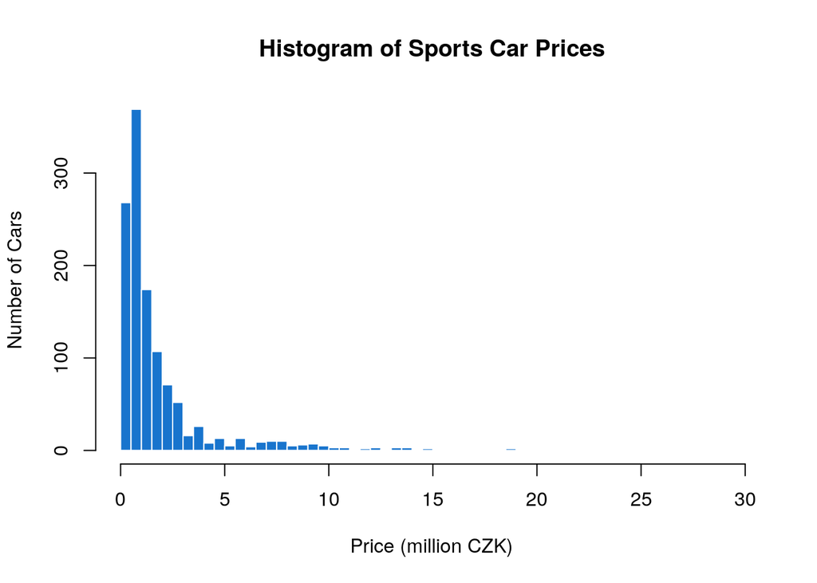

Based on the price analysis of the cars in the dataset obtained from sportovnivozy.cz, we can conclude the following:

- The **average price** of a car in the dataset is **2,001,832 CZK**, while the **median price** is only **999,000 CZK**. This suggests that most cars are priced below average, and a few very expensive cars push the average higher.
- The **cheapest car** in the dataset costs **50,000 CZK**, while the **most expensive car** is priced at **29,900,000 CZK**, giving a total price range of **29,850,000 CZK**.
- The **standard deviation** (**2,970,131 CZK**) shows that the prices of cars are highly dispersed, which is confirmed by the high **kurtosis** of the distribution (**kurtosis = 20.33**).
- The **skewness** of the distribution (**skew = 3.92**) indicates that the dataset contains many lower-priced cars and only a few extremely expensive models, which is typical for luxury and sports car price distributions.

Most sports cars are priced around **1 million CZK**, but there is also a smaller number of exclusive models with significantly higher prices.

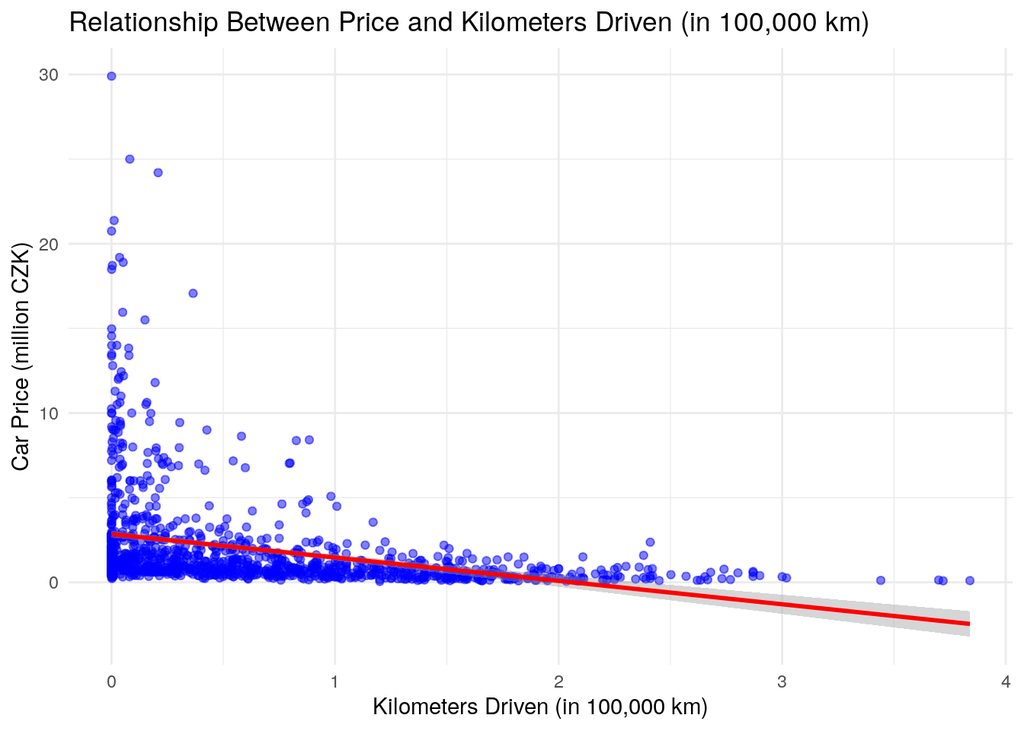

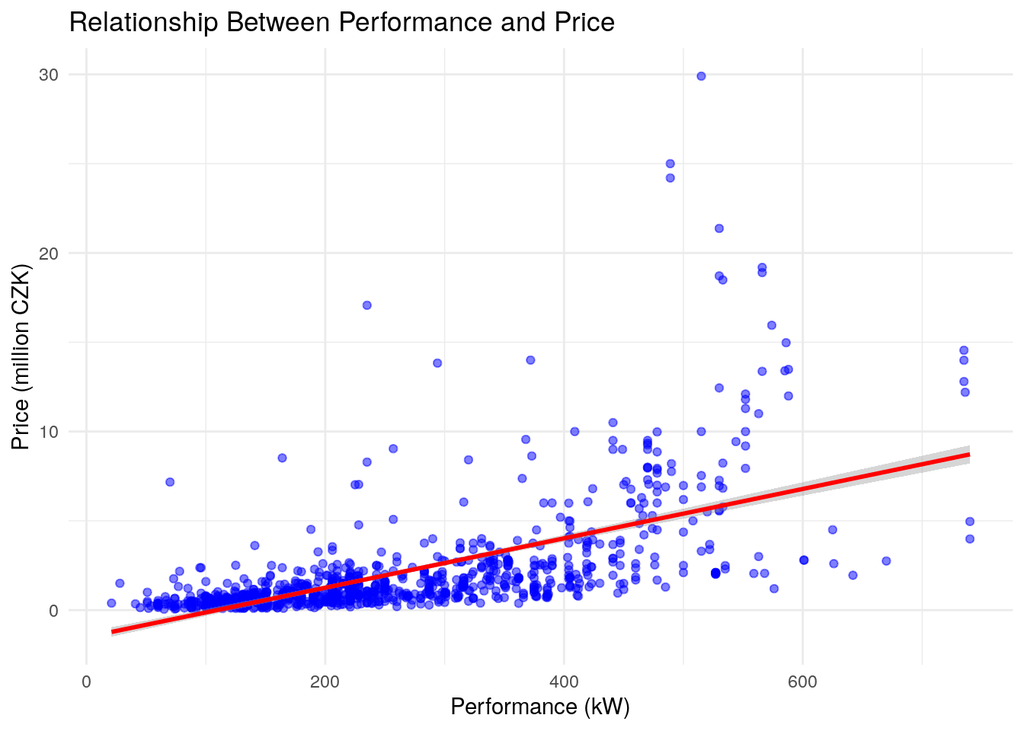

#### Evaluation of Results

The first model examines the relationship between the car price and the kilometers driven. It shows that as the kilometers increase, the price of the car tends to decrease. This is intuitive, as cars with more mileage are generally less valuable. However, the model explains only about 10% of the variation in the price, suggesting that other factors—such as age, condition, or brand—are more significant price drivers than mileage alone.

The second model looks at the relationship between the car’s engine power (in kW) and its price. The results show that cars with higher engine power tend to be more expensive. This is a logical conclusion, as more powerful engines are often found in higher-end models. This model performs better than the first, explaining about 41% of the variation in car prices, indicating that engine power is a more significant factor in determining car prices than the number of kilometers driven.